# Analyzing Corona Data with R

# Die Daten und ihre erste Transformation

```r
library(tidyverse)
```

Die Daten sind unter [on GitHub, a Data Repository provided by the Johns Hopkins CSSE](https://github.com/CSSEGISandData/COVID-19) zu finden; man muss auf den RAW-Button zu knicken, um die URL der CSV-Daten zu erhalten.

```r
corona_data <- read_csv("https://raw.githubusercontent.com/CSSEGISandData/COVID-19/master/csse_covid_19_data/csse_covid_19_time_series/time_series_covid19_confirmed_global.csv")
```

Wir reduzieren die Daten auf die Länder, die uns interessieren:

```r
data <- corona_data %>%
  filter(`Country/Region` == "Germany" | `Country/Region` == "Italy" |  `Country/Region` == "China"  |  `Country/Region` == "US" | `Country/Region` == "France"  | `Country/Region` == "New Zealand" | `Country/Region` == "Israel") %>%
  select(-`Province/State`) %>%
  select(-Lat,-Long) %>%
  group_by(`Country/Region`) %>%
  summarise_each(list(sum))
```

Nun müssen Spalten und Zeilen getauscht werden. Leider wird dann der Header entfernt, die erste Zeile wird dann als Header verwendet:

```r
n <- data$`Country/Region`
data <- as.data.frame(t(data[,-1]))
colnames(data) <- n
data <- tibble::rownames_to_column(data, "Day")
str(data)
```

```
'data.frame':   76 obs. of  8 variables:
 $ Day        : chr  "1/22/20" "1/23/20" "1/24/20" "1/25/20" ...
 $ China      : num  548 643 920 1406 2075 ...
 $ France     : num  0 0 2 3 3 3 4 5 5 5 ...
 $ Germany    : num  0 0 0 0 0 1 4 4 4 5 ...
 $ Israel     : num  0 0 0 0 0 0 0 0 0 0 ...
 $ Italy      : num  0 0 0 0 0 0 0 0 0 2 ...
 $ New Zealand: num  0 0 0 0 0 0 0 0 0 0 ...
 $ US         : num  1 1 2 2 5 5 5 5 5 7 ...
```

Die Datumswerte müssen noch zum Datentyp Datum konvertiert werden:

```r
data <- data %>%
  mutate(Day = as.Date(Day,"%m/%d/%y"))
```

Mit der reshape-Library werden die Daten in ein spezielles Format gebracht, dass wir in diesem Fall benötigen für ggplot2:

```r
library(reshape2)
(d <- melt(data, id.vars="Day"))
```

| Day | variable | value |
| --- | --- | --- |
| 2020-01-22 | China | 548 |
| 2020-01-23 | China | 643 |
| 2020-01-24 | China | 920 |
| 2020-01-25 | China | 1406 |
| 2020-01-26 | China | 2075 |
| 2020-01-27 | China | 2877 |
| 2020-01-28 | China | 5509 |
| 2020-01-29 | China | 6087 |
| 2020-01-30 | China | 8141 |
| 2020-01-31 | China | 9802 |

[output cut: 522 more lines]

# Anzahl Infektionen

Infektionsdaten sollten mit Vorsicht genossen werden:

- Nicht jedes Land hat jeden Tag frische Daten, das RKI in Deutschland bekommt die Daten zum Teil nicht am Wochenende!
- In manchen Ländern werden Tests anders durchgeführt als in anderen Ländern; in Deutschland muss Kontakt zu einer Verdachtsperson oder zur Zeit die Reise in ein Risikogebiet + in beiden Fällen Symptome vorliegen, um getestet zu werden.

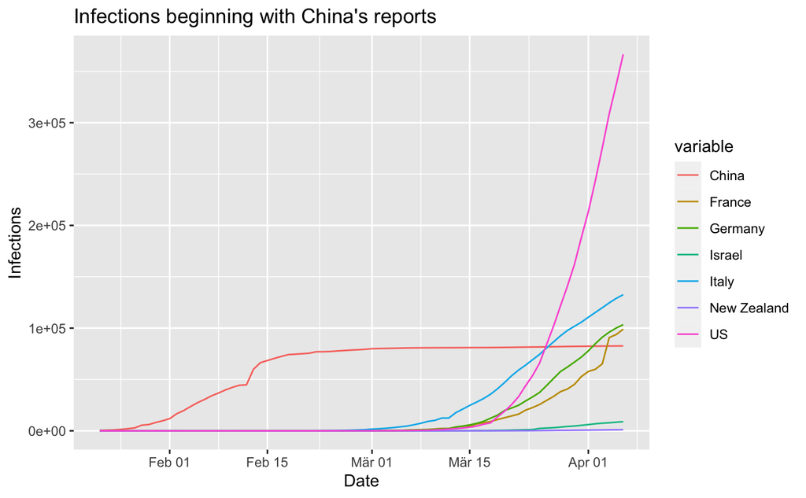

```r
ggplot(d, aes(Day,value, col=variable)) +
  geom_line() +
  ggtitle("Infections beginning with China's reports") +
  xlab("Date") +
  ylab("Infections")
```

In der Untersuchung, die als Inspiration wirkte, wurde die 20. Infektion als Startpunkt genommen:

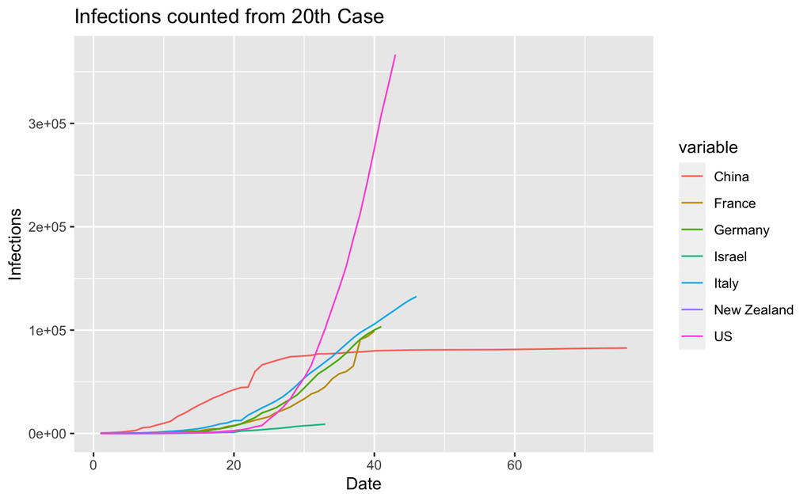

```r
d2 <- d %>%
  filter(value > 19) %>%
  group_by(variable) %>%
  mutate(id = row_number())

ggplot(d2, aes(id,value, col=variable)) +
  geom_line() +
  ggtitle("Infections counted from 20th Case") +
  xlab("Date") +
  ylab("Infections")
```

Die Frage ist, warum gerade 20, warum nicht 21 oder 17? Hier nun einmal von der ersten Infektion aus geplottet:

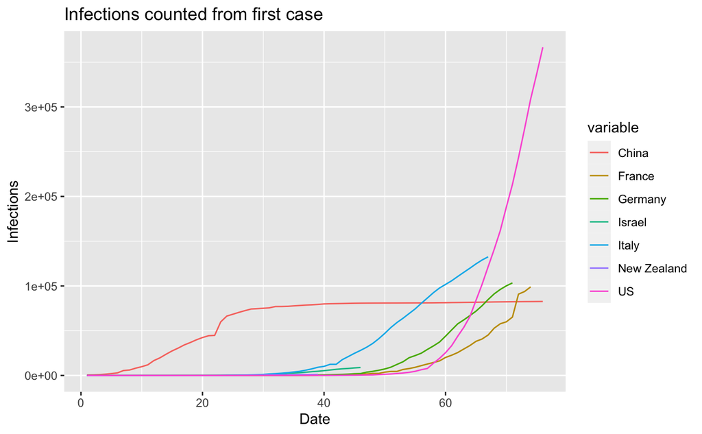

```r
d3 <- d %>%
  filter(value > 0) %>%
  group_by(variable) %>%
  mutate(id = row_number())

# plot
ggplot(d3, aes(id,value, col=variable)) +
  geom_line() +
  ggtitle("Infections counted from first case") +
  xlab("Date") +
  ylab("Infections")
```

Als Log2 auf der Y-Achse:

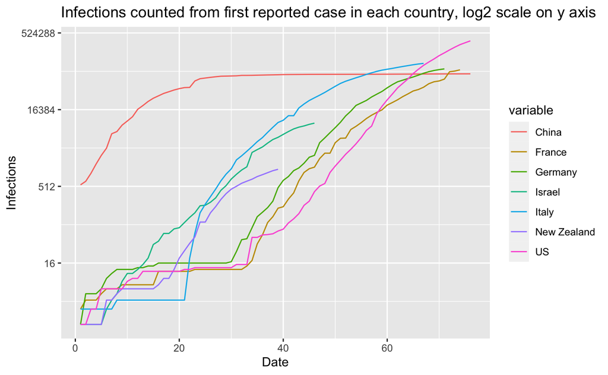

```r
ggplot(d3, aes(id,value, col=variable)) +
  geom_line() +
  scale_y_continuous(trans = 'log2') +
  ggtitle("Infections counted from first reported case in each country, log2 scale on y axis") +
  xlab("Date") +
  ylab("Infections")
```

# Anzahl Tests

Some commentors wanted to see how many tests were performed, and this is a tricky one as [data provided by ourworldindata.org](https://ourworldindata.org/covid-testing) differs in the way how tests are performed and counted:

- In some countries, the number of tested individuals is reported
- In other countries, the number of tests is reported
- and then, there are countries where the data units are completely unclear

In Germany, for example, the high number of tests could be a result of one person being tested several times. Let’s look at the data anyway. The current data is from April 6th, 2020.

```r
library(readxl)
tests <- read_excel("covid-testing-06-Apr.xlsx")
```

```r
(my_tests <- tests %>%
  filter(Entity == "France - units unclear" | Entity == "Germany - samples tested" | Entity == "Italy - units unclear" | Entity == "South Korea - cases tested" | Entity == "United States - specimens tested (CDC)" | Entity == "United States - inconsistent units (COVID Tracking Project)") %>%
   select(Entity,Date, `Cumulative total`,`Cumulative total per million`))
```

| Entity | Date | Cumulative total | Cumulative total per million |
| --- | --- | --- | --- |
| France - units unclear | 2020-03-31 | 224254 | 3412.2037 |
| Germany - samples tested | 2020-03-29 | 918460 | 11127.3927 |
| Italy - units unclear | 2020-04-06 | 721732 | 12205.4236 |
| South Korea - cases tested | 2020-04-06 | 466804 | 9062.9279 |
| United States - inconsistent units (COVID Tracking Project) | 2020-04-05 | 1762032 | 5316.4283 |
| United States - specimens tested (CDC) | 2020-03-28 | 163660 | 493.7973 |

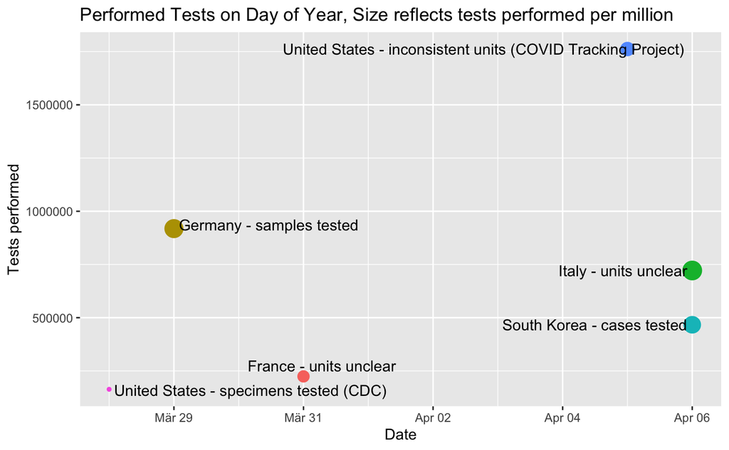

```r
library(ggrepel)
ggplot(my_tests, aes(x = Date, y = `Cumulative total`)) +
    geom_point(aes(color = Entity,  size = `Cumulative total per million`)) +
    geom_text_repel(aes(label=Entity)) + # Repel takes care of putting the labels close to the data points but without leaving the grid
  #scale_y_continuous(trans = 'log2') +
  labs(title="Performed Tests on Day of Year, Size reflects tests performed per million", x ="Date", y = "Tests performed") +
  theme(legend.position = "none")
```

Manche Labels überlappen die Datenpunkte, das sollte noch gefixt werden.

# Tote

```r
# Get the data
corona_deaths <- read_csv("https://raw.githubusercontent.com/CSSEGISandData/COVID-19/master/csse_covid_19_data/csse_covid_19_time_series/time_series_covid19_deaths_global.csv")
```

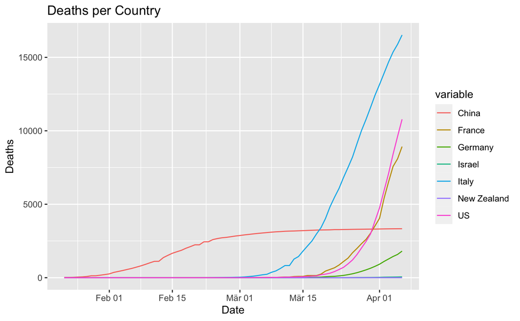

```r
# Transform the data and remove the Diamond Princess
data_deaths <- corona_deaths %>%
  filter(`Country/Region` == "Germany" | `Country/Region` == "Italy" |  `Country/Region` == "China"  |  `Country/Region` == "US" | `Country/Region` == "France" | `Country/Region` == "New Zealand" | `Country/Region` == "Israel") %>%
  filter(`Province/State` !="Diamond Princess" | is.na(`Province/State`)) %>%
   select(-`Province/State`) %>%
  select(-Lat,-Long) %>%
  group_by(`Country/Region`) %>%
  summarise_each(list(sum))

# Swap rows and columns and convert date
n <- data_deaths$`Country/Region`
data_deaths <- as.data.frame(t(data_deaths[,-1]))
colnames(data_deaths) <- n
data_deaths <- tibble::rownames_to_column(data_deaths, "Day")
data_deaths <- data_deaths %>%
  mutate(Day = as.Date(Day,"%m/%d/%y"))

# Melt the data
d_deaths <- melt(data_deaths, id.vars="Day")

# plot
ggplot(d_deaths, aes(Day,value, col=variable)) +
  geom_line() +
  ggtitle("Deaths per Country") +
  xlab("Date") +
  ylab("Deaths")
```

Log2:

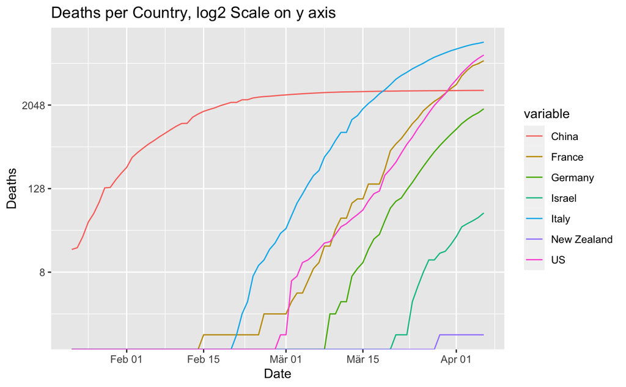

```r
ggplot(d_deaths, aes(Day,value, col=variable)) +
  geom_line() +
  scale_y_continuous(trans = 'log2') +
  ggtitle("Deaths per Country, log2 Scale on y axis") +
  xlab("Date") +
  ylab("Deaths")
```

```r
deaths_from_one <- d_deaths %>%
  filter(value > 0) %>%
  group_by(variable) %>%
  mutate(id = row_number())
```

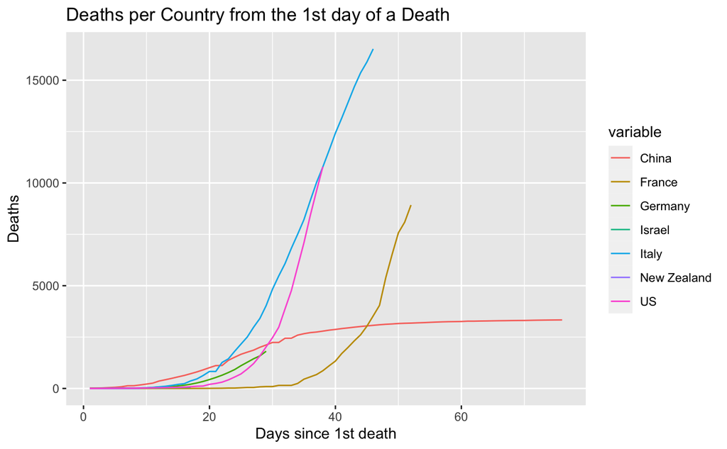

```r
ggplot(deaths_from_one, aes(id,value, col=variable)) +
  geom_line() +
  ggtitle("Deaths per Country from the 1st day of a Death") +
  xlab("Days since 1st death") +
  ylab("Deaths")
```

# Tote im Verhältnis zur Bevölkerung

```r
population <- read_delim("population.csv",  "\t", escape_double = FALSE, trim_ws = TRUE)
```

```r
(population_subset <- population %>%
  filter(`Country` == "China" | `Country` == "France" | `Country` == "Germany" | `Country` == "Italy" | `Country` == "United States" | `Country` == "New Zealand" | `Country` == "Israel") %>%
  select(`Country`,Population) %>%
  mutate(`Country` = replace(`Country`, `Country` == "United States","US")) %>%
  rename(variable = `Country`) %>%
  rename(population = Population)
 )
```

| variable | population |
| --- | --- |
| China | 1439323776 |
| US | 331002651 |
| Germany | 83783942 |
| France | 65273511 |
| Italy | 60461826 |
| Israel | 8655535 |
| New Zealand | 4822233 |

```r
deaths_vs_population <- d_deaths %>%
  left_join(population_subset) %>%
  mutate(value = (value/population)*100000)
```

```
Column `variable` joining factor and character vector, coercing into character vector
```

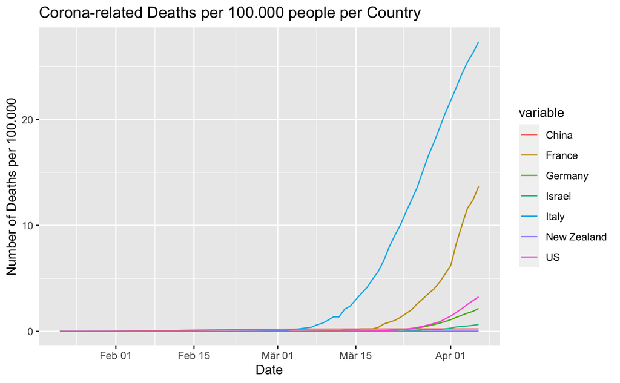

```r
  # plot
ggplot(deaths_vs_population, aes(Day,value, col=variable)) +
  geom_line() +
  ggtitle("Corona-related Deaths per 100.000 people per Country") +
  xlab("Date") +
  ylab("Number of Deaths per 100.000")
```

Log2:

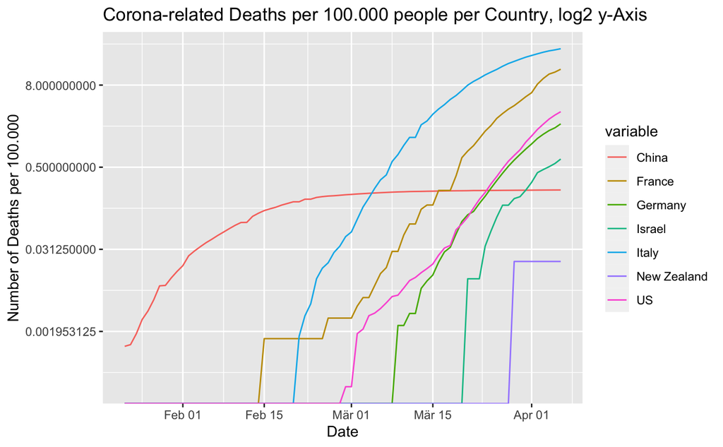

```r
  # plot
ggplot(deaths_vs_population, aes(Day,value, col=variable)) +
  #scale_x_continuous(trans = 'log2') +
  scale_y_continuous(trans = 'log2') +
  geom_line() +
  ggtitle("Corona-related Deaths per 100.000 people per Country, log2 y-Axis") +
  xlab("Date") +
  ylab("Number of Deaths per 100.000")
```

Die Toten werden eventuell unterschiedlich gezählt, je nachdem ob Tote generell getestet werden oder ob nur diejenigen getestet werden, bei denen ein Verdacht bestand.

# Comparing Corona to Influenza: Results III

Die Daten wurden manuell von der [RKI-Seite mit den wöchentlichen Reports gezogen](https://influenza.rki.de/Wochenberichte.aspx). Bei der Influenza handelt es sich in der Regel um mehrere Viren, 2020 zum Beispiel Influenza A(H1N1)pdm09, Influenza A(H3N2) and Influenza B.

```r
grippe <- read_delim("grippe.csv",
    ";", escape_double = FALSE, col_types = cols(date = col_date(format = "%d.%m.%y"),
        infected = col_integer()), trim_ws = TRUE)
```

Zuerst die Infektionen:

```r
flu_vs_influenca_inf <- data %>%
  select(Day,Germany) %>%
  full_join(grippe, c("Day" = "date")) %>%
  filter(Day > "2018-12-31") %>%
  select(-deaths) %>%
  rename(Corona = Germany) %>%
  rename(Influenza = infected)
```

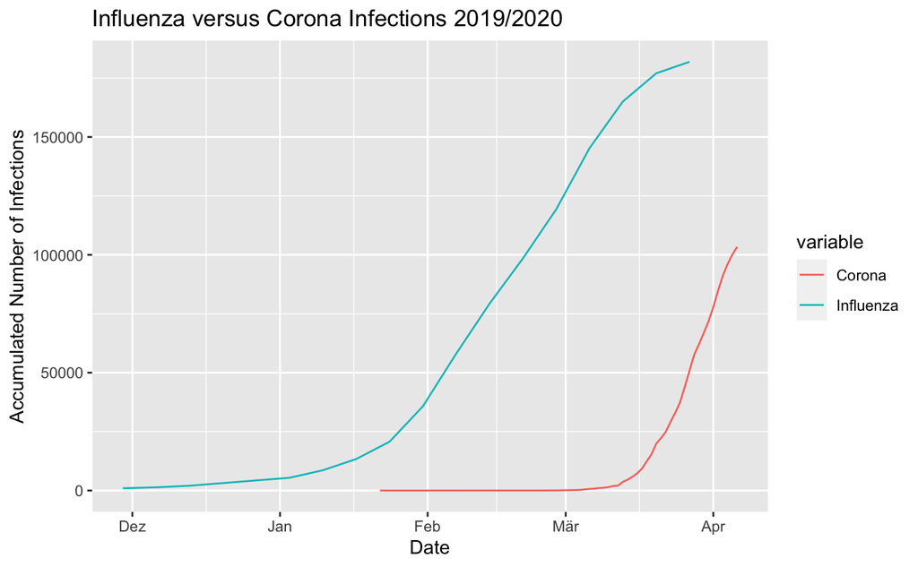

```r
# melt the data
comparison_inf <- melt(flu_vs_influenca_inf, id.vars="Day")

# remove NAs
comparison_inf <- comparison_inf %>%
  filter(!is.na(value))

# plot
ggplot(comparison_inf, aes(Day,value, col=variable)) +
  geom_line()  +
  ggtitle("Influenza versus Corona Infections 2019/2020") +
  xlab("Date") +
  ylab("Accumulated Number of Infections")
```

Nun der Vergleich mit einer ganzen Influenza-Welle, hier 2017/2018, die als besonders hart gilt:

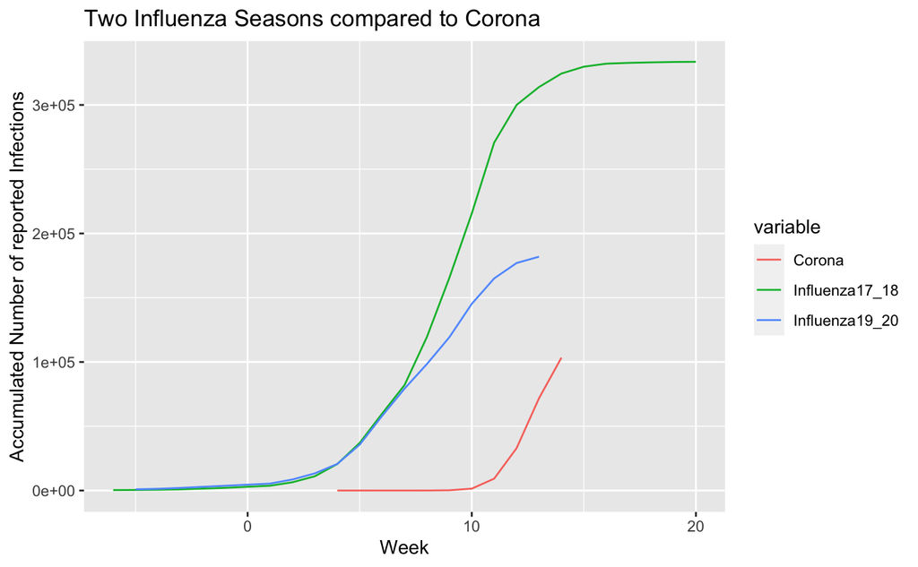

```r
data %>%
  select(Day,Germany) %>%
  full_join(grippe, c("Day" = "date")) %>%
  select(-deaths) %>%
  rename(Corona = Germany) %>%
  rename(Influenza = infected) %>%
  mutate(Influenza17_18 = case_when(Day < "2018-12-31" ~ Influenza)) %>%
  mutate(Influenza19_20 = case_when(Day > "2018-12-31" ~ Influenza)) %>%
  select(-Influenza) %>%
  melt(., id.vars="Day") %>%
  filter(!is.na(value)) %>%
  mutate(week = lubridate::week((Day))) %>%
  mutate(week = if_else(week > 38,week-53,week)) %>%
  group_by(week, variable) %>%
  summarize(value = max(value)) %>%
  ggplot(aes(week,value, col=variable)) +
  geom_line()  +
  ggtitle("Two Influenza Seasons compared to Corona") +
  xlab("Week") +
  ylab("Accumulated Number of reported Infections")
```

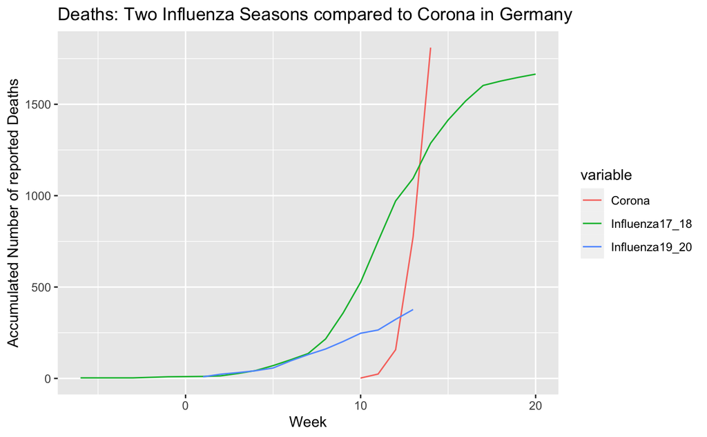

```r
data_deaths %>%
  select(Day,Germany) %>%
  full_join(grippe, c("Day" = "date")) %>%
  select(-infected) %>%
  rename(Corona = Germany) %>%
  rename(Influenza = deaths) %>%
  mutate(Influenza17_18 = case_when(Day < "2018-12-31" ~ Influenza)) %>%
  mutate(Influenza19_20 = case_when(Day > "2018-12-31" ~ Influenza)) %>%
  select(-Influenza) %>%
  melt(., id.vars="Day") %>%
  filter(!is.na(value)) %>%
  filter(value != 0) %>%
  mutate(week = lubridate::week((Day))) %>%
  mutate(week = if_else(week > 38,week-53,week)) %>%
  group_by(week, variable) %>%
  summarize(value = max(value)) %>%
  ggplot(aes(week,value, col=variable)) +
  geom_line()  +
  ggtitle("Deaths: Two Influenza Seasons compared to Corona in Germany") +
  xlab("Week") +
  ylab("Accumulated Number of reported Deaths")
```

Log2:

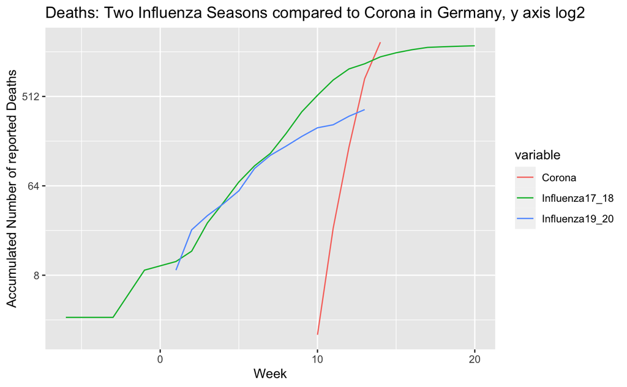

```r
data_deaths %>%
  select(Day,Germany) %>%
  full_join(grippe, c("Day" = "date")) %>%
  select(-infected) %>%
  rename(Corona = Germany) %>%
  rename(Influenza = deaths) %>%
  mutate(Influenza17_18 = case_when(Day < "2018-12-31" ~ Influenza)) %>%
  mutate(Influenza19_20 = case_when(Day > "2018-12-31" ~ Influenza)) %>%
  select(-Influenza) %>%
  melt(., id.vars="Day") %>%
  filter(!is.na(value)) %>%
  filter(value != 0) %>%
  mutate(week = lubridate::week((Day))) %>%
  mutate(week = if_else(week > 38,week-53,week)) %>%
  group_by(week, variable) %>%
  summarize(value = max(value)) %>%
  ggplot(aes(week,value, col=variable)) +
  geom_line()  +
  scale_y_continuous(trans = 'log2') +
  ggtitle("Deaths: Two Influenza Seasons compared to Corona in Germany, y axis log2") +
  xlab("Week") +
  ylab("Accumulated Number of reported Deaths")
```

# Rankings

```r
new_data <- corona_data %>%
  rename(last_day = rev(names(corona_data))[1])
```

```r
new_data %>%
  group_by(`Country/Region`) %>%
  select(-`Province/State`) %>%
  select(-Lat,-Long) %>%
  summarise_each(list(sum)) %>%
  select(`Country/Region`,last_day) %>%
  arrange(desc(last_day))
```

| Country/Region | last_day |
| --- | --- |
| US | 366614 |
| Spain | 136675 |
| Italy | 132547 |
| Germany | 103374 |
| France | 98963 |
| China | 82665 |
| Iran | 60500 |
| United Kingdom | 52279 |
| Turkey | 30217 |
| Switzerland | 21657 |

[output cut: 174 more lines]

```r
new_death_data <- corona_deaths %>%
  rename(last_day = rev(names(corona_deaths))[1])
```

```r
new_death_data %>%
  group_by(`Country/Region`) %>%
  select(-`Province/State`) %>%
  select(-Lat,-Long) %>%
  summarise_each(list(sum)) %>%
  select(`Country/Region`,last_day) %>%
  arrange(desc(last_day))
```

| Country/Region | last_day |
| --- | --- |
| Italy | 16523 |
| Spain | 13341 |
| US | 10783 |
| France | 8926 |
| United Kingdom | 5385 |
| Iran | 3739 |
| China | 3335 |
| Netherlands | 1874 |
| Germany | 1810 |
| Belgium | 1632 |

[output cut: 174 more lines]